# Homework 6

Sarah Younes

As always, I will begin by loading necessary packages. Additionally, I will set my seed for reproducibility.

```r
library(tidyverse)
library(modelr)
library(mgcv)
set.seed(1)
```

## Problem 1

First, I will import and clean the data, including filtering the data to necessary items.

```r
homicide_data =
  read.csv(
    "./data/homicide-data.csv",
    na = "Unknown") |>
  janitor::clean_names() |>
  drop_na() |>
  mutate(
    victim_last = str_to_title(victim_last),
    victim_first = str_to_title(victim_first),
    city_state = paste(city, state, sep = ", "),
    victim_age = as.numeric(victim_age),
    status = case_when(
      disposition == "Closed without arrest" ~ "Solved",
      disposition == "Closed by arrest" ~ "Solved",
      disposition == "Open/No arrest" ~ "Unsolved")) |>
  filter(!(city_state %in% c("Dallas, TX", "Phoenix, AZ", "Kansas City, MO", "Tulsa, OK"))) |>
  filter(victim_race == "White" | victim_race == "Black")
```

```r
regression_data =
  homicide_data |>
  mutate(
    status = case_when(
      status == "Solved" ~ 1,
      status == "Unsolved" ~ 0))

status_fit =
  glm(status ~ victim_age + victim_sex + victim_race, data = regression_data, family = "binomial") |>
  broom::tidy() |>
  mutate(OR = exp(estimate))

status_fit
```

```
## # A tibble: 4 × 6
##   term              estimate std.error statistic   p.value    OR
##   <chr>                <dbl>     <dbl>     <dbl>     <dbl> <dbl>
## 1 (Intercept)       0.708     0.0402      17.6   2.23e- 69 2.03
## 2 victim_age        0.000609  0.000784     0.777 4.37e-  1 1.00
## 3 victim_sexMale   -0.803     0.0331     -24.3   2.80e-130 0.448
## 4 victim_raceWhite  0.798     0.0331      24.1   9.84e-129 2.22
```

## Problem 2

First, I will download the cleaned weather data set as instructed.

```r
weather_df =
  rnoaa::meteo_pull_monitors(
    c("USW00094728"),
    var = c("PRCP", "TMIN", "TMAX"),
    date_min = "2022-01-01",
    date_max = "2022-12-31") |>
  mutate(
    name = recode(id, USW00094728 = "CentralPark_NY"),
    tmin = tmin / 10,
    tmax = tmax / 10) |>
  select(name, id, everything())
```

I will now create a simple linear regression with `tmax` as the outcome and `tmin` and `prcp` as the predictors.

```r
tmax_fit = lm(tmax ~ tmin + prcp, data = weather_df)

tmax_fit
```

```
##
## Call:
## lm(formula = tmax ~ tmin + prcp, data = weather_df)
##
## Coefficients:
## (Intercept)         tmin         prcp
##    8.042803     1.013386    -0.001541
```

Next, I will draw 5,000 bootstrap samples and produce estimates of r-squared using `broom::glance`.

```r
r2_bootstrap =
  weather_df |>
  modelr::bootstrap(n = 5000) |>
  mutate(
    models = map(strap, \(weather_df) lm(tmax ~ tmin + prcp, data = weather_df)),
    results = map(models, broom::glance),
    sample_number = row_number()) |>
  unnest(results) |>
  select(sample_number, r.squared)

r2_bootstrap
```

```
## # A tibble: 5,000 × 2
##    sample_number r.squared
##            <int>     <dbl>
##  1             1     0.898
##  2             2     0.928
##  3             3     0.925
##  4             4     0.931
##  5             5     0.915
##  6             6     0.918
##  7             7     0.922
##  8             8     0.910
##  9             9     0.910
## 10            10     0.939
## # ℹ 4,990 more rows
```

I will draw 5,000 bootstrap samples and produce estimates of log(β̂ 1∗β̂ 2) using `broom::tidy()` and `pivot_wider`.

```r
log_bootstrap =
  weather_df |>
  modelr::bootstrap(n = 5000) |>
  mutate(
    models = map(strap, \(weather_df) lm(tmax ~ tmin + prcp, data = weather_df)),
    results = map(models, broom::tidy),
    sample_number = row_number()) |>
  unnest(results) |>
  filter(term %in% c("prcp", "tmin")) |>
  pivot_wider(
    id_cols = sample_number,
    names_from = term,
    values_from = estimate) |>
  mutate(
    log = log(tmin * prcp))
log_bootstrap
```

```
## # A tibble: 5,000 × 4
##    sample_number  tmin      prcp    log
##            <int> <dbl>     <dbl>  <dbl>
##  1             1 0.998  0.00236   -6.05
##  2             2 0.988  0.00103   -6.89
##  3             3 1.02  -0.00200  NaN
##  4             4 1.02  -0.00681  NaN
##  5             5 1.02   0.000945  -6.95
##  6             6 0.997  0.00776   -4.86
##  7             7 1.01   0.000538  -7.52
##  8             8 1.02  -0.00110  NaN
##  9             9 1.04  -0.00472  NaN
## 10            10 1.01   0.000396  -7.83
## # ℹ 4,990 more rows
```

Since ∗β̂ 2 is negative, 66.08 % of estimates of log from the bootstrap samples were negative and thus returned NaN.

Now, I will plot the distribution of the estimates of r-squared and log(β̂ 1∗β̂ 2) from the bootstrap samples.

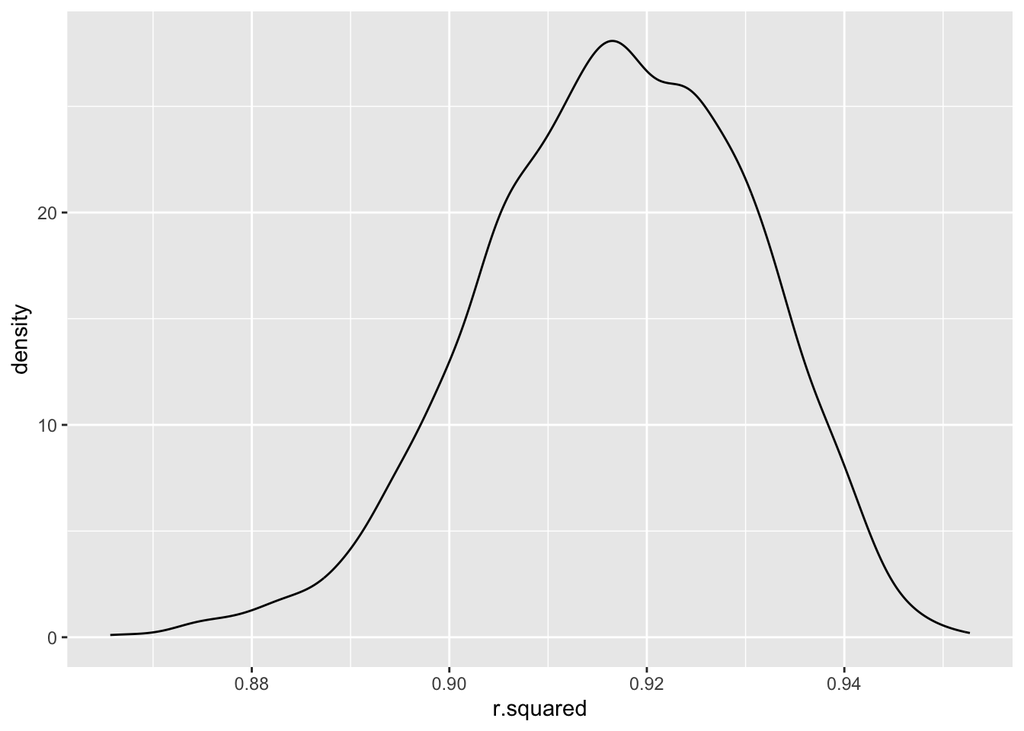

```r
r2_bootstrap |>
  ggplot(aes(x = r.squared)) + geom_density()
```

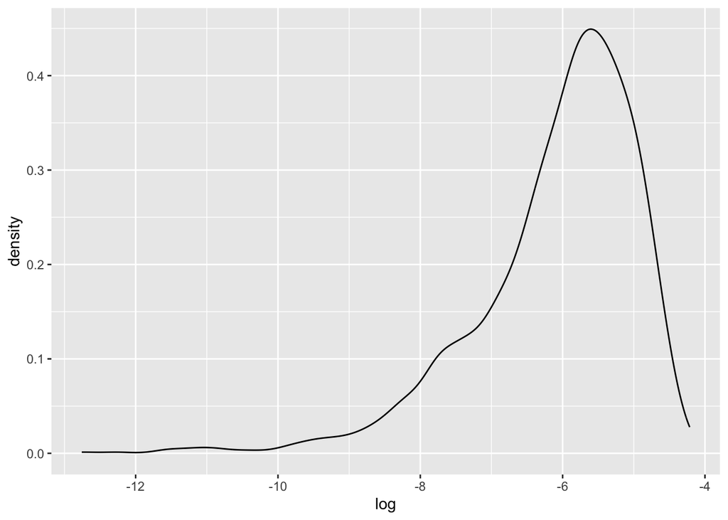

```r
log_bootstrap |>
  ggplot(aes(x = log)) + geom_density()
```

Finally, I will identify the 2.5% and 97.5% quantiles to provide a 95% confidence interval for r-squared and log(β̂ 1∗β̂ 2). However, I dropped negative log values from the bootstrap sample to construct confidence intervals for estimates that are not missing.

```r
r2_bootstrap_ci =
  r2_bootstrap |>
  mutate(
    ci_lower = quantile(r.squared, 0.025),
    ci_upper = quantile(r.squared, 0.975))

r2_bootstrap_ci
```

```
## # A tibble: 5,000 × 4
##    sample_number r.squared ci_lower ci_upper
##            <int>     <dbl>    <dbl>    <dbl>
##  1             1     0.898    0.889    0.941
##  2             2     0.928    0.889    0.941
##  3             3     0.925    0.889    0.941
##  4             4     0.931    0.889    0.941
##  5             5     0.915    0.889    0.941
##  6             6     0.918    0.889    0.941
##  7             7     0.922    0.889    0.941
##  8             8     0.910    0.889    0.941
##  9             9     0.910    0.889    0.941
## 10            10     0.939    0.889    0.941
## # ℹ 4,990 more rows
```

```r
log_bootstrap_ci =
  log_bootstrap |>
  drop_na(log) |>
  mutate(
    ci_lower = quantile(log, 0.025, na.rm = TRUE),
    ci_upper = quantile(log, 0.975, na.rm = TRUE))

log_bootstrap_ci
```

```
## # A tibble: 1,696 × 6
##    sample_number  tmin     prcp   log ci_lower ci_upper
##            <int> <dbl>    <dbl> <dbl>    <dbl>    <dbl>
##  1             1 0.998 0.00236  -6.05    -8.88    -4.60
##  2             2 0.988 0.00103  -6.89    -8.88    -4.60
##  3             5 1.02  0.000945 -6.95    -8.88    -4.60
##  4             6 0.997 0.00776  -4.86    -8.88    -4.60
##  5             7 1.01  0.000538 -7.52    -8.88    -4.60
##  6            10 1.01  0.000396 -7.83    -8.88    -4.60
##  7            12 0.984 0.00825  -4.81    -8.88    -4.60
##  8            14 1.02  0.000886 -7.01    -8.88    -4.60
##  9            15 1.00  0.00582  -5.14    -8.88    -4.60
## 10            17 1.01  0.00200  -6.20    -8.88    -4.60
## # ℹ 1,686 more rows
```

## Problem 3

I will import and clean the birthweight data set. Data cleaning involves removing “Unknown” race values and converting numeric values to factors.

```r
birthweight_df =
  read_csv("./data/birthweight.csv") |>
  filter(frace != 9) |>
  mutate(
    frace = as.factor(frace),
    mrace = as.factor(mrace))

## I tried this code but it messed up my t-test: mutate(babysex = case_match(babysex, 1 ~ "male", 2 ~ "female"), malform = case_match(malform, 0 ~ "absent", 1 ~ "present"))
```

I will use a combination of a data-driven and theory/hypothesis-driven modeling process to propose a regression model for birthweight.

I will use run statistical tests to look at the relationship between the continuous outcome, `bwt`, and each independent variable. However, I am automatically excluding `pnumlbw` and `pnumsga` as potential independent variables because their values across the entire sample were all 0, so there cannot be any trends between them and `bwt`.

For continuous independent variables, I will run Pearson’s correlation using `cor.test`; for binary categorical independent variables, I will run independent samples t-tests using `t.test`; and for categorical independent variables with three or more values, I will run ANOVA using `aov`.

Here are the steps I will take and criteria I will use:

1. I will run the statistical tests.
2. I will only consider p-values that are statistically significant at p<0.05.
3. I will use the following criteria to narrow down my independent variables:
   - For statistically significant continuous independent variables (tested with Pearson’s correlation): the correlation coefficient estimate must be >0.7 to indicate a strong correlation.
   - For statistically significant categorical independent variables (tested with independent samples t-tests and ANOVA): I will look at the existing literature online to determine have the strongest relationships AND there must be enough values of all the categories in the birthweight data set to notice differences in birthweight by category.

I will include the variables with the strongest numeric and/or theoretical relationships in my model based on the criteria above.

Here are my statistical tests:

```r
cor.test(pull(birthweight_df, bwt), pull(birthweight_df, bhead), method = "pearson") |> broom::tidy()
```

```
## # A tibble: 1 × 8
##   estimate statistic p.value parameter conf.low conf.high method     alternative
##      <dbl>     <dbl>   <dbl>     <int>    <dbl>     <dbl> <chr>      <chr>
## 1    0.747      74.0       0      4340    0.734     0.760 Pearson's… two.sided
```

```r
cor.test(pull(birthweight_df, bwt), pull(birthweight_df, blength), method = "pearson") |> broom::tidy()
```

```
## # A tibble: 1 × 8
##   estimate statistic p.value parameter conf.low conf.high method     alternative
##      <dbl>     <dbl>   <dbl>     <int>    <dbl>     <dbl> <chr>      <chr>
## 1    0.743      73.2       0      4340    0.730     0.756 Pearson's… two.sided
```

```r
cor.test(pull(birthweight_df, bwt), pull(birthweight_df, delwt), method = "pearson") |> broom::tidy()
```

```
## # A tibble: 1 × 8
##   estimate statistic  p.value parameter conf.low conf.high method    alternative
##      <dbl>     <dbl>    <dbl>     <int>    <dbl>     <dbl> <chr>     <chr>
## 1    0.288      19.8 1.22e-83      4340    0.260     0.315 Pearson'… two.sided
```

```r
cor.test(pull(birthweight_df, bwt), pull(birthweight_df, fincome), method = "pearson") |> broom::tidy()
```

```
## # A tibble: 1 × 8
##   estimate statistic  p.value parameter conf.low conf.high method    alternative
##      <dbl>     <dbl>    <dbl>     <int>    <dbl>     <dbl> <chr>     <chr>
## 1    0.155      10.3 1.26e-24      4340    0.125     0.183 Pearson'… two.sided
```

```r
cor.test(pull(birthweight_df, bwt), pull(birthweight_df, gaweeks), method = "pearson") |> broom::tidy()
```

```
## # A tibble: 1 × 8
##   estimate statistic   p.value parameter conf.low conf.high method   alternative
##      <dbl>     <dbl>     <dbl>     <int>    <dbl>     <dbl> <chr>    <chr>
## 1    0.412      29.8 9.69e-178      4340    0.387     0.437 Pearson… two.sided
```

```r
cor.test(pull(birthweight_df, bwt), pull(birthweight_df, menarche), method = "pearson") |> broom::tidy()
```

```
## # A tibble: 1 × 8
##   estimate statistic p.value parameter conf.low conf.high method     alternative
##      <dbl>     <dbl>   <dbl>     <int>    <dbl>     <dbl> <chr>      <chr>
## 1  -0.0244     -1.61   0.108      4340  -0.0541   0.00532 Pearson's… two.sided
```

```r
cor.test(pull(birthweight_df, bwt), pull(birthweight_df, mheight), method = "pearson") |> broom::tidy()
```

```
## # A tibble: 1 × 8
##   estimate statistic  p.value parameter conf.low conf.high method    alternative
##      <dbl>     <dbl>    <dbl>     <int>    <dbl>     <dbl> <chr>     <chr>
## 1    0.192      12.9 2.18e-37      4340    0.163     0.221 Pearson'… two.sided
```

```r
cor.test(pull(birthweight_df, bwt), pull(birthweight_df, momage), method = "pearson") |> broom::tidy()
```

```
## # A tibble: 1 × 8
##   estimate statistic  p.value parameter conf.low conf.high method    alternative
##      <dbl>     <dbl>    <dbl>     <int>    <dbl>     <dbl> <chr>     <chr>
## 1    0.136      9.03 2.57e-19      4340    0.106     0.165 Pearson'… two.sided
```

```r
cor.test(pull(birthweight_df, bwt), pull(birthweight_df, parity), method = "pearson") |> broom::tidy()
```

```
## # A tibble: 1 × 8
##   estimate statistic p.value parameter conf.low conf.high method     alternative
##      <dbl>     <dbl>   <dbl>     <int>    <dbl>     <dbl> <chr>      <chr>
## 1 -0.00837    -0.552   0.581      4340  -0.0381    0.0214 Pearson's… two.sided
```

```r
cor.test(pull(birthweight_df, bwt), pull(birthweight_df, ppbmi), method = "pearson") |> broom::tidy()
```

```
## # A tibble: 1 × 8
##   estimate statistic  p.value parameter conf.low conf.high method    alternative
##      <dbl>     <dbl>    <dbl>     <int>    <dbl>     <dbl> <chr>     <chr>
## 1   0.0939      6.22 5.56e-10      4340   0.0644     0.123 Pearson'… two.sided
```

```r
cor.test(pull(birthweight_df, bwt), pull(birthweight_df, ppwt), method = "pearson") |> broom::tidy()
```

```
## # A tibble: 1 × 8
##   estimate statistic  p.value parameter conf.low conf.high method    alternative
##      <dbl>     <dbl>    <dbl>     <int>    <dbl>     <dbl> <chr>     <chr>
## 1    0.183      12.3 5.69e-34      4340    0.154     0.211 Pearson'… two.sided
```

```r
cor.test(pull(birthweight_df, bwt), pull(birthweight_df, smoken), method = "pearson") |> broom::tidy()
```

```
## # A tibble: 1 × 8
##   estimate statistic     p.value parameter conf.low conf.high method alternative
##      <dbl>     <dbl>       <dbl>     <int>    <dbl>     <dbl> <chr>  <chr>
## 1  -0.0756     -5.00 0.000000607      4340   -0.105   -0.0460 Pears… two.sided
```

```r
cor.test(pull(birthweight_df, bwt), pull(birthweight_df, wtgain), method = "pearson") |> broom::tidy()
```

```
## # A tibble: 1 × 8
##   estimate statistic  p.value parameter conf.low conf.high method    alternative
##      <dbl>     <dbl>    <dbl>     <int>    <dbl>     <dbl> <chr>     <chr>
## 1    0.247      16.8 1.73e-61      4340    0.219     0.275 Pearson'… two.sided
```

```r
t.test(pull(birthweight_df, bwt), pull(birthweight_df, babysex)) |> broom::tidy()
```

```
## # A tibble: 1 × 10
##   estimate estimate1 estimate2 statistic p.value parameter conf.low conf.high
##      <dbl>     <dbl>     <dbl>     <dbl>   <dbl>     <dbl>    <dbl>     <dbl>
## 1    3113.     3114.      1.49      401.       0     4341.    3098.     3128.
## # ℹ 2 more variables: method <chr>, alternative <chr>
```

```r
t.test(pull(birthweight_df, bwt), pull(birthweight_df, malform)) |> broom::tidy()
```

```
## # A tibble: 1 × 10
##   estimate estimate1 estimate2 statistic p.value parameter conf.low conf.high
##      <dbl>     <dbl>     <dbl>     <dbl>   <dbl>     <dbl>    <dbl>     <dbl>
## 1    3114.     3114.   0.00345      401.       0     4341.    3099.     3130.
## # ℹ 2 more variables: method <chr>, alternative <chr>
```

```r
aov(birthweight_df$bwt ~ birthweight_df$frace) |> broom::tidy()
```

```
## # A tibble: 2 × 6
##   term                    df       sumsq    meansq statistic   p.value
##   <chr>                <dbl>       <dbl>     <dbl>     <dbl>     <dbl>
## 1 birthweight_df$frace     4   99855116. 24963779.      104.  6.99e-85
## 2 Residuals             4337 1038797077.   239520.       NA  NA
```

```r
aov(birthweight_df$bwt ~ birthweight_df$mrace) |> broom::tidy()
```

```
## # A tibble: 2 × 6
##   term                    df       sumsq    meansq statistic   p.value
##   <chr>                <dbl>       <dbl>     <dbl>     <dbl>     <dbl>
## 1 birthweight_df$mrace     3  102185313. 34061771.      143.  4.22e-88
## 2 Residuals             4338 1036466880.   238927.       NA  NA
```

```r
bwt_model = lm(bwt ~ bhead + blength + babysex + mrace, data = birthweight_df)
```

I will plot the residuals:

```r
birthweight_df |>
 modelr::add_residuals(bwt_model)
```

```
## # A tibble: 4,342 × 21
##    babysex bhead blength   bwt delwt fincome frace gaweeks malform menarche
##      <dbl> <dbl>   <dbl> <dbl> <dbl>   <dbl> <fct>   <dbl>   <dbl>    <dbl>
##  1       2    34      51  3629   177      35 1        39.9       0       13
##  2       1    34      48  3062   156      65 2        25.9       0       14
##  3       2    36      50  3345   148      85 1        39.9       0       12
##  4       1    34      52  3062   157      55 1        40         0       14
##  5       2    34      52  3374   156       5 1        41.6       0       13
##  6       1    33      52  3374   129      55 1        40.7       0       12
##  7       2    33      46  2523   126      96 2        40.3       0       14
##  8       2    33      49  2778   140       5 1        37.4       0       12
##  9       1    36      52  3515   146      85 1        40.3       0       11
## 10       1    33      50  3459   169      75 2        40.7       0       12
## # ℹ 4,332 more rows
## # ℹ 11 more variables: mheight <dbl>, momage <dbl>, mrace <fct>, parity <dbl>,
## #   pnumlbw <dbl>, pnumsga <dbl>, ppbmi <dbl>, ppwt <dbl>, smoken <dbl>,
## #   wtgain <dbl>, resid <dbl>
```

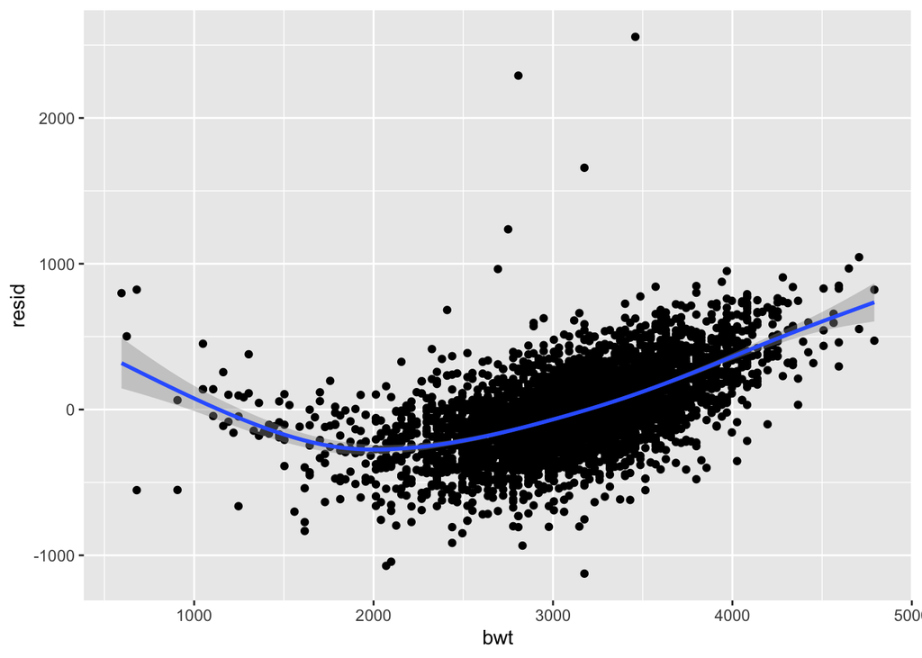

```r
birthweight_df |>
  modelr::add_residuals(bwt_model) |>
  ggplot(aes(x = bwt, y = resid)) + geom_point() + geom_smooth()
```

I will plot the fitted values:

```r
modelr::add_predictions(birthweight_df, bwt_model)
```

```
## # A tibble: 4,342 × 21
##    babysex bhead blength   bwt delwt fincome frace gaweeks malform menarche
##      <dbl> <dbl>   <dbl> <dbl> <dbl>   <dbl> <fct>   <dbl>   <dbl>    <dbl>
##  1       2    34      51  3629   177      35 1        39.9       0       13
##  2       1    34      48  3062   156      65 2        25.9       0       14
##  3       2    36      50  3345   148      85 1        39.9       0       12
##  4       1    34      52  3062   157      55 1        40         0       14
##  5       2    34      52  3374   156       5 1        41.6       0       13
##  6       1    33      52  3374   129      55 1        40.7       0       12
##  7       2    33      46  2523   126      96 2        40.3       0       14
##  8       2    33      49  2778   140       5 1        37.4       0       12
##  9       1    36      52  3515   146      85 1        40.3       0       11
## 10       1    33      50  3459   169      75 2        40.7       0       12
## # ℹ 4,332 more rows
## # ℹ 11 more variables: mheight <dbl>, momage <dbl>, mrace <fct>, parity <dbl>,
## #   pnumlbw <dbl>, pnumsga <dbl>, ppbmi <dbl>, ppwt <dbl>, smoken <dbl>,
## #   wtgain <dbl>, pred <dbl>
```

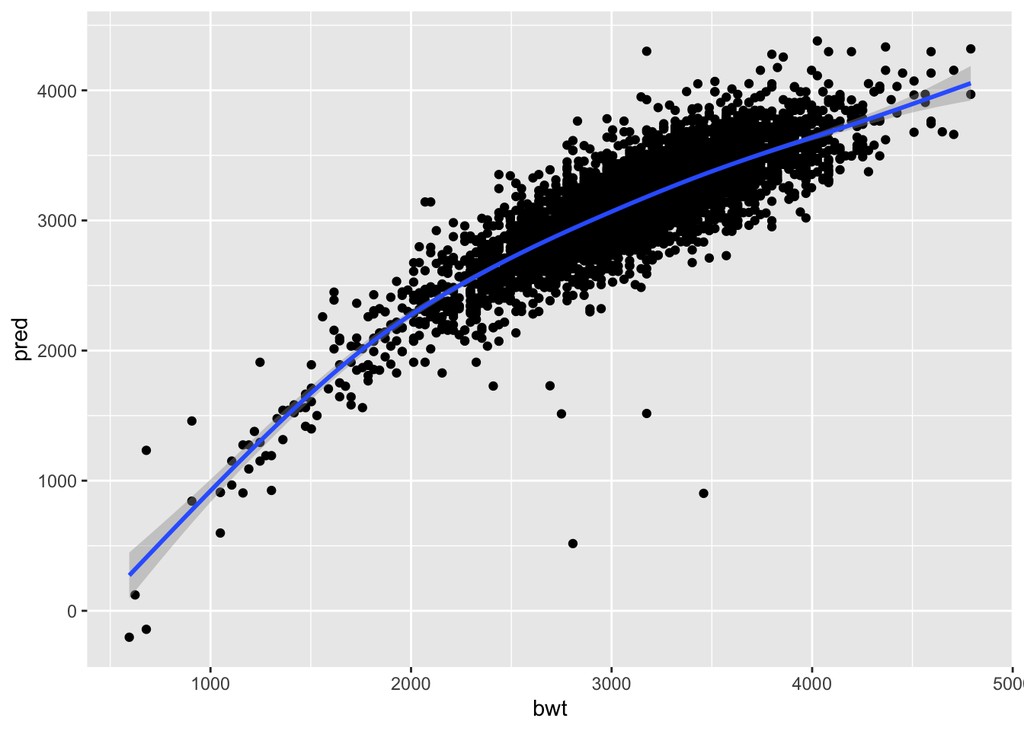

```r
birthweight_df |>
  modelr::add_predictions(bwt_model) |>
  ggplot(aes(x = bwt, y = pred)) + geom_point() + geom_smooth()
```

## delete the below

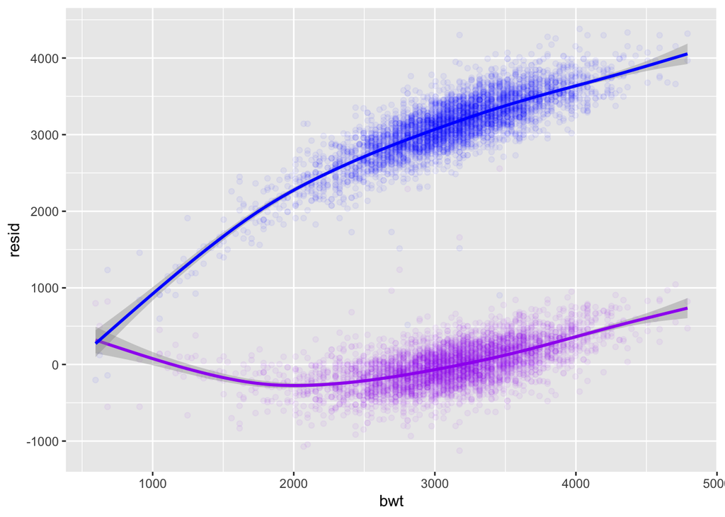

```r
resid_pred =
  birthweight_df |>
  modelr::add_predictions(bwt_model) |>
  modelr::add_residuals(bwt_model) |>
  select(bwt, resid, pred, everything())

resid_pred |>
  ggplot(aes(x = bwt)) +
  geom_point(aes(y = resid), color = "purple", alpha = 0.05) +
  geom_smooth(aes(y = resid), color = "purple") +
  geom_point(aes(y = pred), color = "blue", alpha = 0.05) +
  geom_smooth(aes(y = pred), color = "blue")
```

Now, I will compare my model to two others:

```r
option_1 = lm(bwt ~ blength + gaweeks, data = birthweight_df)

option_2 = lm(bwt ~ bhead + blength + babysex + (bhead * blength * babysex), data = birthweight_df)
```

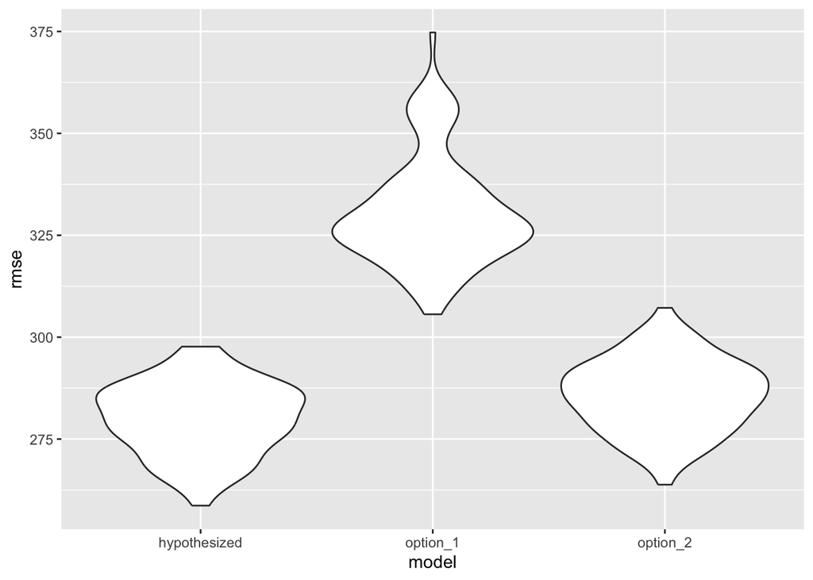

```r
cv_df =
  crossv_mc(birthweight_df, 100)

cv_df =
  cv_df |>
  mutate(
    train = map(train, as_tibble),
    test = map(test, as_tibble))

cv_df =
  cv_df |>
  mutate(
    hypothesized = map(train, \(df) lm(bwt ~ bhead + blength + babysex + mrace, data = birthweight_df)),
    option_1 = map(train, \(df) lm(bwt ~ blength + gaweeks, data = birthweight_df)),
    option_2 = map(train, \(df) lm(bwt ~ bhead + blength + babysex + (bhead * blength * babysex), data = birthweight_df))) |>
  mutate(
    rmse_hypothesized = map2_dbl(hypothesized, test, \(mod, df) rmse(model = mod, data = df)),
    rmse_option_1 = map2_dbl(option_1, test, \(mod, df) rmse(model = mod, data = df)),
    rmse_option_2 = map2_dbl(option_2, test, \(mod, df) rmse(model = mod, data = df)))

cv_df |>
  select(starts_with("rmse")) |>
  pivot_longer(
    everything(),
    names_to = "model",
    values_to = "rmse",
    names_prefix = "rmse_") |>
  mutate(model = fct_inorder(model)) |>
  ggplot(aes(x = model, y = rmse)) + geom_violin()
```